# #TidyTuesday Submission

Data Science for Biologists, Spring 2020

Nicholas Paterna

March 22, 2020

### TidyTuesday Week 12

Hi, this is my fourth time attempting to make a figure for #TidyTuesday! I am a student at Rowan University in Biochemistry with *a smidge* of experience in coding thanks to [Dr. Stephanie Spielman](https://twitter.com/stephspiel). R is my first language and I am very happy to be learning it, I hope to work in Bioinformatics one day possibly Medical Genomics. I am open to criticism or helpful tips in trimming my code!!

```r
tidy_path <- "/Users/nickpaterna/datascience/TidyTuesday/Week_12/"
#This variable will tell the figure where to save when I apply ggsave!

figure_name <- "tidytues_week12.png"
#Rather than re-typing this into ggsave I can just use this!
```

## Avoid Hard-coding!

One of the most important things that my professor stresses is a complete aversion to HARD-CODING, or explicitly re-typing code in a large script. It might not make a lot of sense to apply these practices on a small assignment but the more often I apply it the easier to apply it is in the future! (Also the second visible code chunk gives my submission some more flavor!)

```r
office_ratings %>%
  select(season, imdb_rating, total_votes) %>%
#Isolating columns of interest.
  group_by(season) %>%
  summarize(avg_rating = mean(imdb_rating),
            tot_votes = sum(total_votes)) -> tidy_office
```

```
## select: dropped 3 variables (episode, title, air_date)
```

```
## group_by: one grouping variable (season)
```

```
## summarize: now 9 rows and 3 columns, ungrouped
```

```r
#Creates two new columns with total votes & average rating, summarized by season.

tidy_office
```

```
## # A tibble: 9 x 3
##   season avg_rating tot_votes
##    <dbl>      <dbl>     <dbl>
## 1      1       8.02     19172
## 2      2       8.44     57874
## 3      3       8.57     56193
## 4      4       8.6      33916
## 5      5       8.49     55919
## 6      6       8.22     48270
## 7      7       8.32     48743
## 8      8       7.67     37113
## 9      9       7.96     42610
```

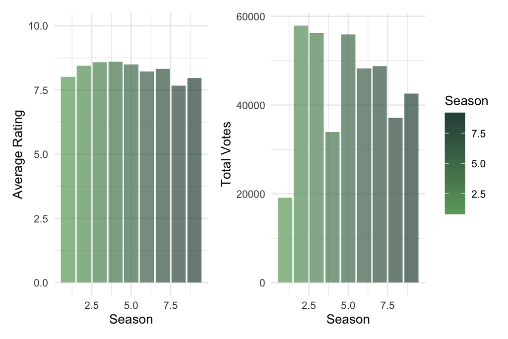

```r
#Displaying the tidy data to show changes.

tidy_office %>%
  ggplot(aes(x = season, y = avg_rating, fill = season)) +
  geom_col(alpha = 0.7) +
  scale_fill_gradient(low = "#6ca66a", high ="#2f4f48") +
#I love this function, I use the ColorPicker on Google to find the Hex#s for the colors I want to see in my figure.
  labs(x = "Season", y = "Average Rating") +
  theme(legend.position = "none") +
  ylim(0 ,10) -> half_officeplot

tidy_office %>%
  ggplot(aes(x = season, y = tot_votes, fill = season)) +
  geom_col(alpha = 0.7) +
  scale_fill_gradient(low = "#6ca66a", high ="#2f4f48") +
  labs(x = "Season", y = "Total Votes", fill = "Season") -> sechalf_officeplot

(half_officeplot + sechalf_officeplot) -> office_plot
#Using this awesome package called 'patchwork' I was able to make two separate plots, save them as variables, and then glue them together with a little electronic scrapbooking.

ggsave(paste0(tidy_path, figure_name), office_plot, height = 4, width = 6)
office_plot
```

I almost forgot to make my plot this week because I have been SO engrossed in Animal Crossing: New Horizon. I am not going to lie, I would love to see some AC themed datasets in future #TidyTuesday repos.

I have never seen The Office, I know shame on me, so I decided to go for simplicity with observations I could understand without utilizing the Shrute package. I couldn’t decide between the average rating per season or the total number of votes so I decided to just throw both together! I used a package that we utilized in class called `patchwork` and it is, for lack of better word, delicious. I hope you enjoy my plot, you can find this and future entries on my [GitHub](https://github.com/npaterna/datascience/tree/master/TidyTuesday).